# Intro Datenanalyse 2

Jan-Philipp Kolb

06 Mai, 2019

# Einfache Graphiken erstellen

## Ein Plot sagt mehr als 1000 Worte

- Grafisch gestützte Datenanalyse ist toll
- Gute Plots können zu einem besseren Verständnis beitragen
- Einen Plot zu generieren geht schnell
- Einen guten Plot zu machen kann sehr lange dauern
- Mit R Plots zu generieren macht Spaß
- Mit R erstellte Plots haben hohe Qualität
- Fast jeder Plottyp wird von R unterstützt
- R kennt eine große Menge an Exportformaten für Grafiken

## Plot ist nicht gleich Plot

- Bereits das base Package bringt eine große Menge von Plot Funktionen mit
- Das lattice Packet erweitert dessen Funktionalität
- Eine weit über diese Einführung hinausgehende Übersicht findet sich in Murrell, P (2006): R Graphics.

## CRAN Task Views

- Zu einigen Themen sind alle Möglichkeiten in R zusammengestellt. ([Übersicht der Task Views](https://cran.r-project.org/web/views/))
- Zur Zeit gibt es 35 Task Views
- [Alle Pakete eines Task Views können mit folgendem Befehl installiert werden:](https://mran.microsoft.com/rpackages/)

```r
install.packages("ctv")
library("ctv")
install.views("Bayesian")
```

## Task View zu Thema [Graphiken](https://cran.r-project.org/web/views/Graphics.html)

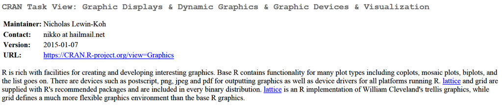

## Datensatz

```r
library(mlmRev)
data(Chem97)
```

- [lea] Local Education Authority - a factor
- [school] School identifier - a factor
- [student] Student identifier - a factor
- [score] Point score on A-level Chemistry in 1997
- [gender] Student’s gender
- [age] Age in month, centred at 222 months or 18.5 years
- [gcsescore] Average GCSE score of individual.
- [gcsecnt] Average GCSE score of individual, centered at mean.

## Histogramm - Die Funktion hist()

Wir erstellen ein Histogramm der Variable gcsescore:

```r
?hist
```

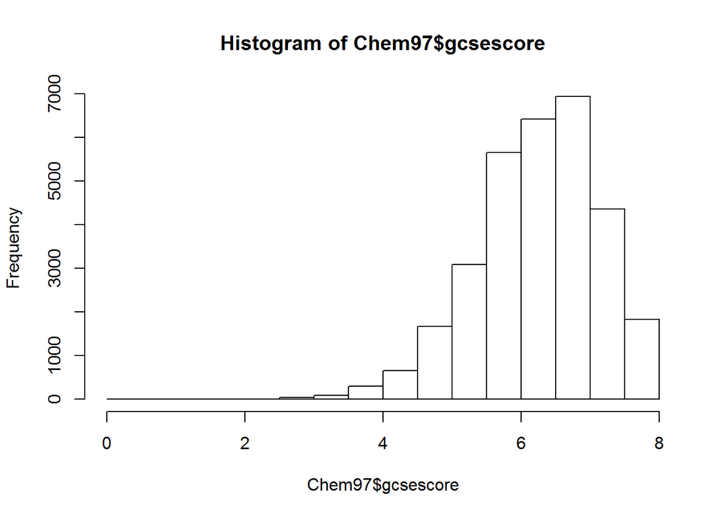

```r
hist(Chem97$gcsescore)
```

## Graphik speichern

- Mit dem button Export in Rstudio kann man die Grafik speichern.

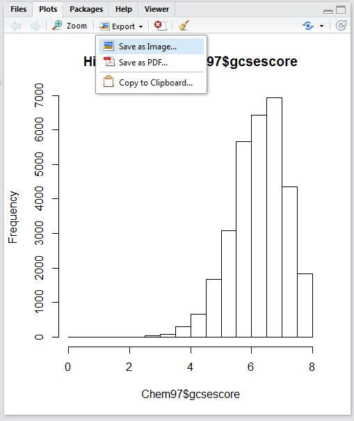

## Befehl um Graphik zu speichern

- Alternativ auch bspw. mit den Befehlen `png`, `pdf` oder `jpeg`

```r
png("Histogramm.png")
hist(Chem97$gcsescore)
dev.off()
```

## Histogramme

- Die Funktion `hist()` plottet ein Histogramm der Daten
- Der Funktion muss mindestens ein Beobachtungsvektor übergeben werden
- `hist()` hat noch sehr viel mehr Argumente, die alle (sinnvolle) default values haben

| Argument | Bedeutung | Beispiel |
| --- | --- | --- |
| main | Überschrift | main=“Hallo Welt” |
| xlab | x-Achsenbeschriftung | xlab=“x-Werte” |
| ylab | y-Achsenbeschriftung | ylab=“y-Werte” |
| col | Farbe | col=“blue” |

## Histogramm

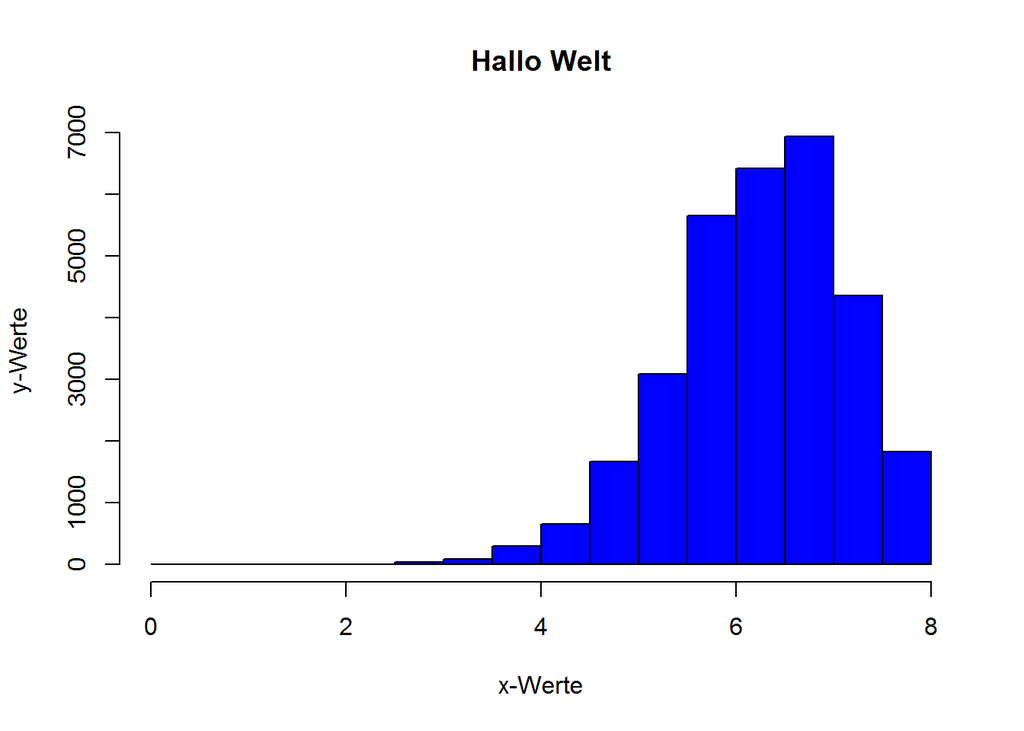

```r
hist(Chem97$gcsescore,col="blue",
     main="Hallo Welt",ylab="y-Werte", xlab="x-Werte")
```

Weitere Argumente:

```r
?plot
# oder
?par
```

## Barplot

- Die Funktion `barplot()` erzeugt aus einer Häufigkeitstabelle einen Barplot
- Ist das übergebene Tabellen-Objekt zweidimensional wird ein bedingter Barplot erstellt

```r
tabScore <- table(Chem97$score)
```

```r
barplot(tabScore)
```

## Barplots und barcharts

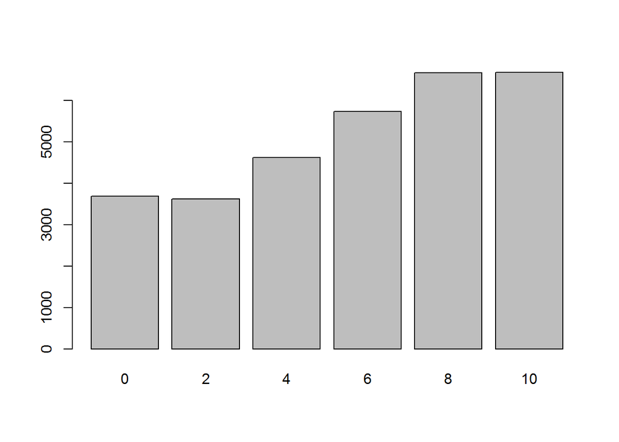

```r
barplot(tabScore)
```

## Mehr Farben:

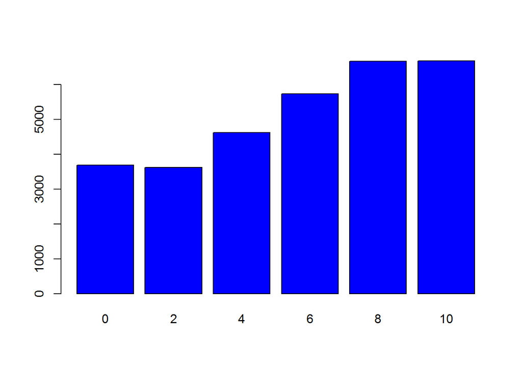

```r
barplot(tabScore,col=rgb(0,0,1))
```

## Grüne Farbe

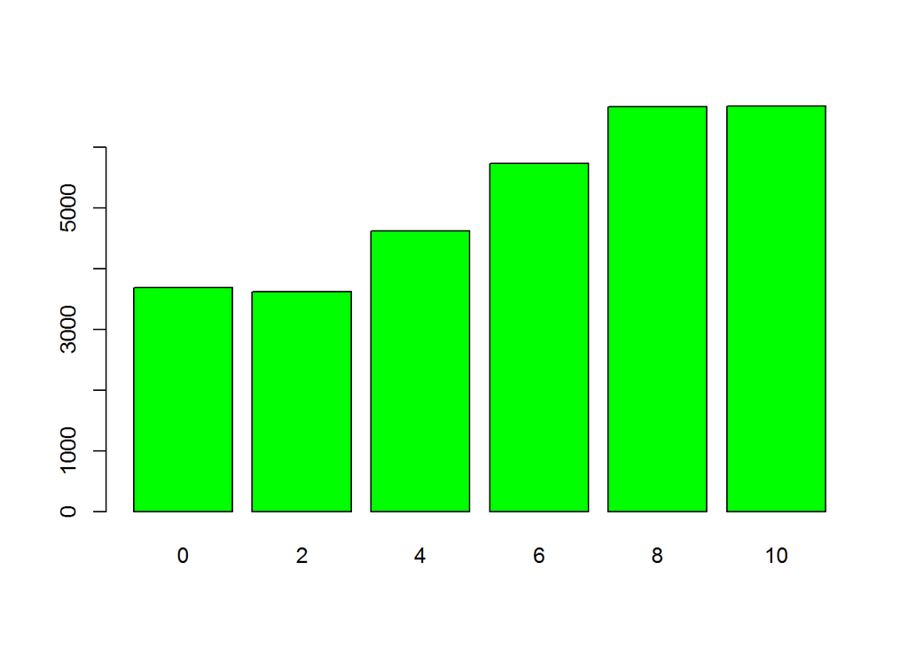

```r
barplot(tabScore,col=rgb(0,1,0))
```

## Rote Farbe

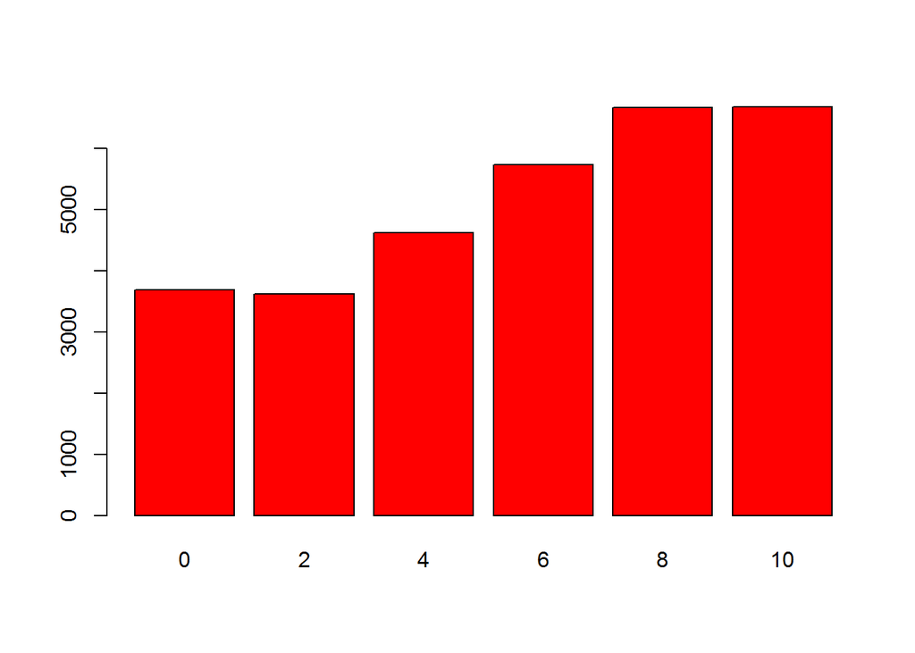

```r
barplot(tabScore,col=rgb(1,0,0))
```

## Transparent

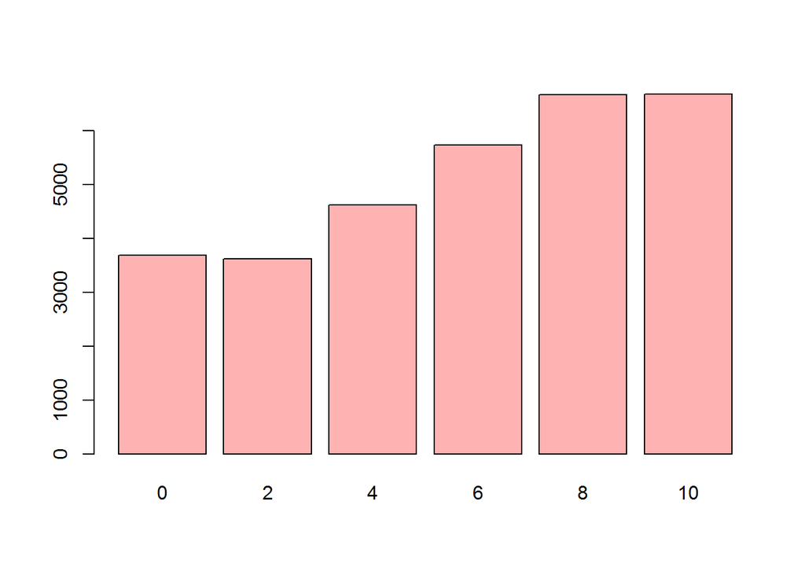

```r
barplot(tabScore,col=rgb(1,0,0,.3))
```

## Boxplot

- Einen einfachen Boxplot erstellt man mit `boxplot()`
- Auch `boxplot()` muss mindestens ein Beobachtungsvektor übergeben werden

```r
?boxplot
```

## Horizontaler Boxplot

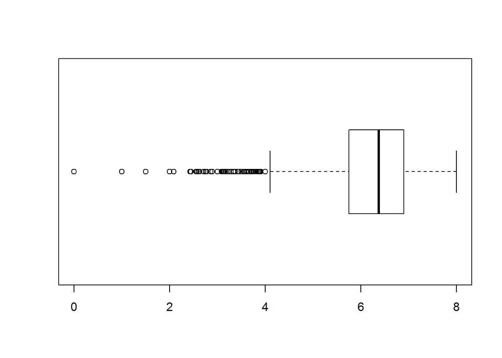

```r
boxplot(Chem97$gcsescore,
horizontal=TRUE)
```

- [Erklärung zu Boxplots](http://edoc.hu-berlin.de/dissertationen/gruenwald-andreas-2005-01-17/HTML/chapter2.html)

## Beispiel grupierter Boxplot

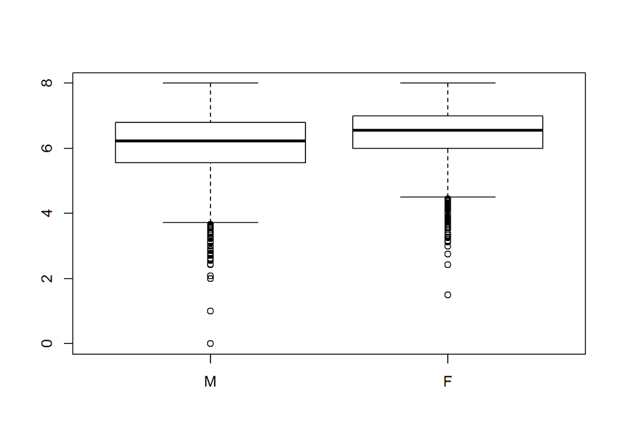

```r
boxplot(Chem97$gcsescore~Chem97$gender)
```

## Alternativen zu Boxplot

```r
# Beispieldaten erzeugen
x <- rnorm(100)
y <- rnorm(100)
```

`vioplot`

- Baut auf Boxplot auf
- Zusätzlich Informationen über Dichte der Daten
- Dichte wird über Kernel Methode berechnet.
- weißer Punkt - Median
- Je weiter die Ausdehnung, desto größer ist die Dichte an dieser Stelle.

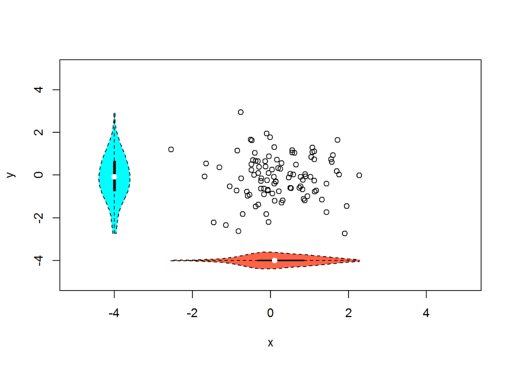

```r
library(vioplot)
plot(x, y, xlim=c(-5,5), ylim=c(-5,5))
vioplot(x, col="tomato", horizontal=TRUE, at=-4,
        add=TRUE,lty=2, rectCol="gray")
vioplot(y, col="cyan", horizontal=FALSE, at=-4,
        add=TRUE,lty=2)
```

## Alternativen zum Boxplot

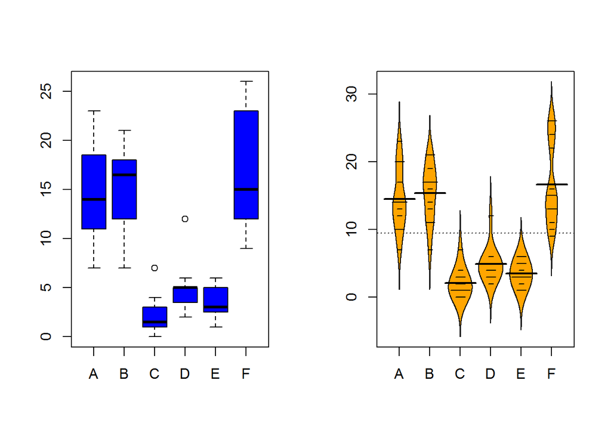

```r
library(beanplot)
par(mfrow = c(1,2))
boxplot(count~spray,data=InsectSprays,col="blue")
beanplot(count~spray,data=InsectSprays,col="orange")
```

## Grafiken für bedingte, bi- und multivariate Verteilungen - Scatterplots

- Ein einfacher two-way scatterplot kann mit der Funktion `plot()` erstellt werden
- `plot()` muss mindestens ein x und ein y Beobachtungsvektor übergeben werden
- Um die Farbe der Plot-Symbole anzupassen gibt es die Option `col` (Farbe als character oder numerisch)
- Die Plot-Symbole selbst können mit `pch` (plotting character) angepasst werden (character oder numerisch)
- Die Achenbeschriftungen (labels) werden mit `xlab` und `ylab` definiert

# Die lineare Regression

## Die lineare Regression

Maindonald - [DataAnalysis](https://cran.r-project.org/doc/contrib/usingR.pdf)

- Einführung in R
- Datenanalyse
- Statistische Modelle
- Inferenzkonzepte
- Regression mit einem Prädiktor
- Multiple lineare Regression
- Ausweitung des linearen Modells
- …

## Lineare Regression in R - Beispieldatensatz

John H. Maindonald and W. John Braun

DAAG - [Data Analysis and Graphics Data and Functions](http://cran.ms.unimelb.edu.au/web/packages/DAAG/DAAG.pdf)

```r
install.packages("DAAG")
```

```r
library("DAAG")
data(roller)
```

Hilfe für den `roller` Datensatz:

```r
?roller
```

```r
roller
```

## Variablen des `mtcars` Datensatzes

- mpg - Miles/(US) gallon
- cyl - Number of cylinders
- disp - Displacement (cu.in.)
- hp - Gross horsepower
- drat - Rear axle ratio
- wt - Weight (1000 lbs)
- qsec - 1/4 mile time
- vs - Engine (0 = V-shaped, 1 = straight)
- am - Transmission (0 = automatic, 1 = manual)
- gear - Number of forward gears
- carb - Number of carburetors

## Datensatz `mtcars`

|  | mpg | cyl | disp | hp | drat | wt | qsec | vs | am | gear | carb |
| --- | --- | --- | --- | --- | --- | --- | --- | --- | --- | --- | --- |
| Mazda RX4 | 21.0 | 6 | 160.0 | 110 | 3.90 | 2.620 | 16.46 | 0 | 1 | 4 | 4 |
| Mazda RX4 Wag | 21.0 | 6 | 160.0 | 110 | 3.90 | 2.875 | 17.02 | 0 | 1 | 4 | 4 |
| Datsun 710 | 22.8 | 4 | 108.0 | 93 | 3.85 | 2.320 | 18.61 | 1 | 1 | 4 | 1 |
| Hornet 4 Drive | 21.4 | 6 | 258.0 | 110 | 3.08 | 3.215 | 19.44 | 1 | 0 | 3 | 1 |
| Hornet Sportabout | 18.7 | 8 | 360.0 | 175 | 3.15 | 3.440 | 17.02 | 0 | 0 | 3 | 2 |
| Valiant | 18.1 | 6 | 225.0 | 105 | 2.76 | 3.460 | 20.22 | 1 | 0 | 3 | 1 |
| Duster 360 | 14.3 | 8 | 360.0 | 245 | 3.21 | 3.570 | 15.84 | 0 | 0 | 3 | 4 |
| Merc 240D | 24.4 | 4 | 146.7 | 62 | 3.69 | 3.190 | 20.00 | 1 | 0 | 4 | 2 |
| Merc 230 | 22.8 | 4 | 140.8 | 95 | 3.92 | 3.150 | 22.90 | 1 | 0 | 4 | 2 |
| Merc 280 | 19.2 | 6 | 167.6 | 123 | 3.92 | 3.440 | 18.30 | 1 | 0 | 4 | 4 |
| Merc 280C | 17.8 | 6 | 167.6 | 123 | 3.92 | 3.440 | 18.90 | 1 | 0 | 4 | 4 |
| Merc 450SE | 16.4 | 8 | 275.8 | 180 | 3.07 | 4.070 | 17.40 | 0 | 0 | 3 | 3 |
| Merc 450SL | 17.3 | 8 | 275.8 | 180 | 3.07 | 3.730 | 17.60 | 0 | 0 | 3 | 3 |
| Merc 450SLC | 15.2 | 8 | 275.8 | 180 | 3.07 | 3.780 | 18.00 | 0 | 0 | 3 | 3 |
| Cadillac Fleetwood | 10.4 | 8 | 472.0 | 205 | 2.93 | 5.250 | 17.98 | 0 | 0 | 3 | 4 |
| Lincoln Continental | 10.4 | 8 | 460.0 | 215 | 3.00 | 5.424 | 17.82 | 0 | 0 | 3 | 4 |
| Chrysler Imperial | 14.7 | 8 | 440.0 | 230 | 3.23 | 5.345 | 17.42 | 0 | 0 | 3 | 4 |
| Fiat 128 | 32.4 | 4 | 78.7 | 66 | 4.08 | 2.200 | 19.47 | 1 | 1 | 4 | 1 |
| Honda Civic | 30.4 | 4 | 75.7 | 52 | 4.93 | 1.615 | 18.52 | 1 | 1 | 4 | 2 |
| Toyota Corolla | 33.9 | 4 | 71.1 | 65 | 4.22 | 1.835 | 19.90 | 1 | 1 | 4 | 1 |
| Toyota Corona | 21.5 | 4 | 120.1 | 97 | 3.70 | 2.465 | 20.01 | 1 | 0 | 3 | 1 |
| Dodge Challenger | 15.5 | 8 | 318.0 | 150 | 2.76 | 3.520 | 16.87 | 0 | 0 | 3 | 2 |
| AMC Javelin | 15.2 | 8 | 304.0 | 150 | 3.15 | 3.435 | 17.30 | 0 | 0 | 3 | 2 |
| Camaro Z28 | 13.3 | 8 | 350.0 | 245 | 3.73 | 3.840 | 15.41 | 0 | 0 | 3 | 4 |
| Pontiac Firebird | 19.2 | 8 | 400.0 | 175 | 3.08 | 3.845 | 17.05 | 0 | 0 | 3 | 2 |
| Fiat X1-9 | 27.3 | 4 | 79.0 | 66 | 4.08 | 1.935 | 18.90 | 1 | 1 | 4 | 1 |
| Porsche 914-2 | 26.0 | 4 | 120.3 | 91 | 4.43 | 2.140 | 16.70 | 0 | 1 | 5 | 2 |
| Lotus Europa | 30.4 | 4 | 95.1 | 113 | 3.77 | 1.513 | 16.90 | 1 | 1 | 5 | 2 |
| Ford Pantera L | 15.8 | 8 | 351.0 | 264 | 4.22 | 3.170 | 14.50 | 0 | 1 | 5 | 4 |
| Ferrari Dino | 19.7 | 6 | 145.0 | 175 | 3.62 | 2.770 | 15.50 | 0 | 1 | 5 | 6 |
| Maserati Bora | 15.0 | 8 | 301.0 | 335 | 3.54 | 3.570 | 14.60 | 0 | 1 | 5 | 8 |
| Volvo 142E | 21.4 | 4 | 121.0 | 109 | 4.11 | 2.780 | 18.60 | 1 | 1 | 4 | 2 |

## Verteilungen für zwei Variablen von `mtcars`

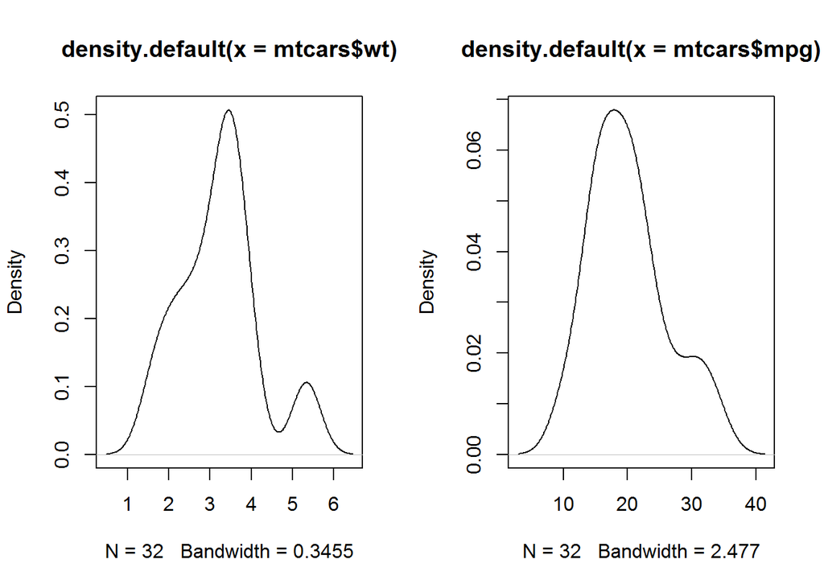

```r
par(mfrow=c(1,2))
plot(density(mtcars$wt)); plot(density(mtcars$mpg))
```

## Ein einfaches Regressionsmodell

### Abhängige Variable - Meilen pro Gallone (`mpg`)

### Unabhängige Variable - Gewicht (`wt`)

```r
m1 <- lm(mpg ~ wt,data=mtcars)
m1
```

```
##
## Call:
## lm(formula = mpg ~ wt, data = mtcars)
##
## Coefficients:
## (Intercept)           wt
##      37.285       -5.344
```

## Die Modellformel

### Modell ohne Achsenabschnitt

```r
m2 <- lm(mpg ~ - 1 + wt,data=mtcars)
summary(m2)$coefficients
```

```
##    Estimate Std. Error  t value    Pr(>|t|)
## wt 5.291624  0.5931801 8.920771 4.55314e-10
```

### Weitere Variablen hinzufügen

```r
m3 <- lm(mpg ~ wt + cyl,data=mtcars)
summary(m3)$coefficients
```

```
##              Estimate Std. Error   t value     Pr(>|t|)
## (Intercept) 39.686261  1.7149840 23.140893 3.043182e-20
## wt          -3.190972  0.7569065 -4.215808 2.220200e-04
## cyl         -1.507795  0.4146883 -3.635972 1.064282e-03
```

## Summary des Modells

```r
summary(m3)
```

```
##
## Call:
## lm(formula = mpg ~ wt + cyl, data = mtcars)
##
## Residuals:
##     Min      1Q  Median      3Q     Max
## -4.2893 -1.5512 -0.4684  1.5743  6.1004
##
## Coefficients:
##             Estimate Std. Error t value Pr(>|t|)
## (Intercept)  39.6863     1.7150  23.141  < 2e-16 ***
## wt           -3.1910     0.7569  -4.216 0.000222 ***
## cyl          -1.5078     0.4147  -3.636 0.001064 **
## ---
## Signif. codes:  0 '***' 0.001 '**' 0.01 '*' 0.05 '.' 0.1 ' ' 1
##
## Residual standard error: 2.568 on 29 degrees of freedom
## Multiple R-squared:  0.8302, Adjusted R-squared:  0.8185
## F-statistic: 70.91 on 2 and 29 DF,  p-value: 6.809e-12
```

## R arbeitet mit Objekten

- `m3` ist nun ein spezielles Regressions-Objekt
- Auf dieses Objekt können nun verschiedene Funktionen angewendet werden

```r
predict(m3) # Vorhersage
```

```
##           Mazda RX4       Mazda RX4 Wag          Datsun 710
##            22.27914            21.46545            26.25203
##      Hornet 4 Drive   Hornet Sportabout             Valiant
##            20.38052            16.64696            19.59873
##          Duster 360           Merc 240D            Merc 230
##            16.23213            23.47588            23.60352
##            Merc 280           Merc 280C          Merc 450SE
##            19.66255            19.66255            14.63665
##          Merc 450SL         Merc 450SLC  Cadillac Fleetwood
##            15.72158            15.56203            10.87130
## Lincoln Continental   Chrysler Imperial            Fiat 128
##            10.31607            10.56816            26.63494
##         Honda Civic      Toyota Corolla       Toyota Corona
##            28.50166            27.79965            25.78934
##    Dodge Challenger         AMC Javelin          Camaro Z28
##            16.39168            16.66291            15.37057
##    Pontiac Firebird           Fiat X1-9       Porsche 914-2
##            15.35461            27.48055            26.82640
##        Lotus Europa      Ford Pantera L        Ferrari Dino
##            28.82714            17.50852            21.80050
##       Maserati Bora          Volvo 142E
##            16.23213            24.78418
```

```r
resid(m3) # Residuen
```

```
##           Mazda RX4       Mazda RX4 Wag          Datsun 710
##         -1.27914467         -0.46544677         -3.45202624
##      Hornet 4 Drive   Hornet Sportabout             Valiant
##          1.01948376          2.05304242         -1.49872807
##          Duster 360           Merc 240D            Merc 230
##         -1.93213120          0.92411952         -0.80351937
##            Merc 280           Merc 280C          Merc 450SE
##         -0.46254751         -1.86254751          1.76335487
##          Merc 450SL         Merc 450SLC  Cadillac Fleetwood
##          1.57842434         -0.36202705         -0.47129800
## Lincoln Continental   Chrysler Imperial            Fiat 128
##          0.08393115          4.13184435          5.76505710
##         Honda Civic      Toyota Corolla       Toyota Corona
##          1.89833840          6.10035227         -4.28933528
##    Dodge Challenger         AMC Javelin          Camaro Z28
##         -0.89167980         -1.46291244         -2.07056872
##    Pontiac Firebird           Fiat X1-9       Porsche 914-2
##          3.84538614         -0.18055052         -0.82640123
##        Lotus Europa      Ford Pantera L        Ferrari Dino
##          1.57285924         -1.70852005         -2.10049885
##       Maserati Bora          Volvo 142E
##         -1.23213120         -3.38417906
```

## Residuenplot

- Sind Annahmen des linearen Regressionsmodells verletzt?
- Dies ist der Fall, wenn ein Muster abweichend von einer Linie zu erkennen ist.
- Hier ist der Datensatz sehr klein

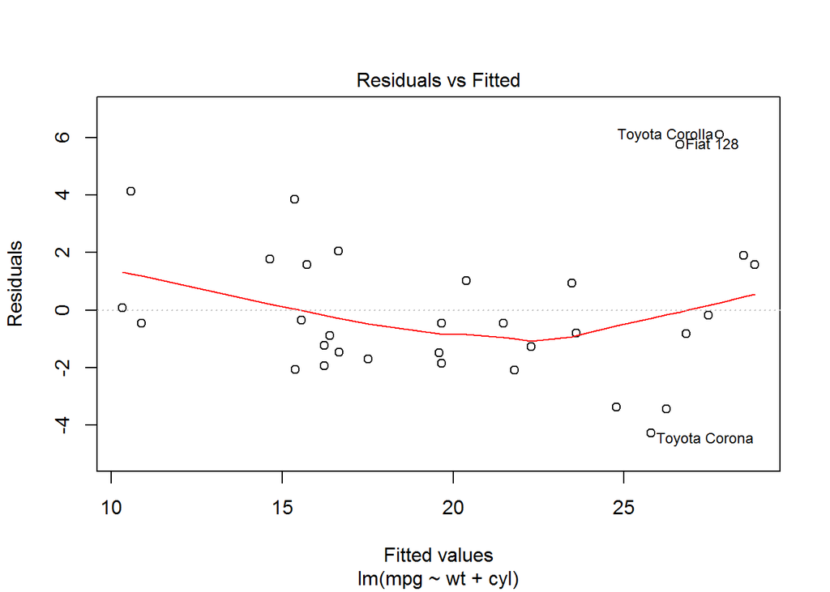

```r
plot(m3,1)
```

## Residuenplot

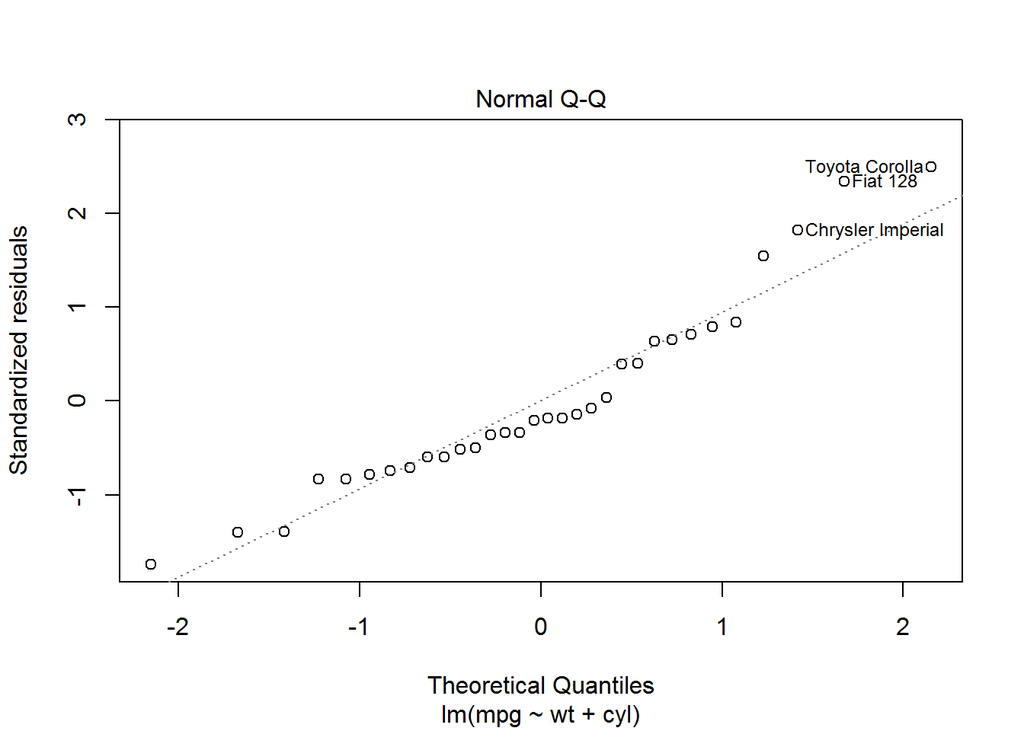

```r
plot(m3,2)
```

- Wenn die Residuen normalverteilt sind sollten sie auf einer Linie liegen.

## [Weitere Möglichkeiten die Formel zu spezifizieren](https://cran.r-project.org/web/packages/Formula/vignettes/Formula.pdf)

### Interaktionseffekt

```r
# effect of cyl and interaction effect:
m3a<-lm(mpg~wt*cyl,data=mtcars)

# only interaction effect:
m3b<-lm(mpg~wt:cyl,data=mtcars)
```

### Den Logarithmus nehmen

```r
m3d<-lm(mpg~log(wt),data=mtcars)
```

## Ein Modell mit Interaktionseffekt

-`disp` - Hubraum

```r
m3d<-lm(mpg~wt*disp,data=mtcars)
m3dsum <- summary(m3d)
m3dsum$coefficients
```

```
##                Estimate  Std. Error   t value     Pr(>|t|)
## (Intercept) 44.08199770 3.123062627 14.114990 2.955567e-14
## wt          -6.49567966 1.313382622 -4.945763 3.216705e-05
## disp        -0.05635816 0.013238696 -4.257078 2.101721e-04
## wt:disp      0.01170542 0.003255102  3.596022 1.226988e-03
```

## [Interaktionen untersuchen](https://cran.r-project.org/web/packages/jtools/vignettes/interactions.html)

```r
install.packages("jtools")
```

```r
library(jtools)
interact_plot(m3d, pred = "wt", modx = "disp")
```

- Mit einem kontinuierlichen Moderator (in unserem Fall `Disp`) erhält man drei Zeilen - 1 Standardabweichung über und unter dem Mittelwert und der Mittelwert selbst.

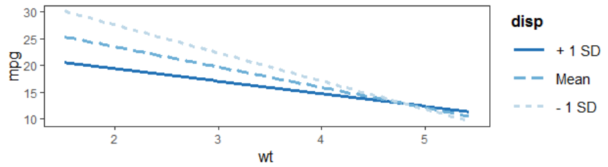

## Das Paket `interplot`

```r
library(interplot)
```

- Effekt wird auf die y-Achse geplottet - `wt` auf der x-Achse

```r
interplot(m = m3a, var1 = "wt", var2 = "disp", hist = TRUE)
```

- Eine detailliertere Beschreibung ist in der [**`interplot` Vignette**](https://cran.r-project.org/web/packages/interplot/vignettes/interplot-vignette.html) zu bekommen.

## Beispiel: Objektorientierung

- `m3` ist nun ein spezielles Regressionsobjekt
- Verschiedene Funktionen können auf dieses Objekt angewendet werden

```r
predict(m3) # Prediction
resid(m3) # Residuals
```

```
##         Mazda RX4     Mazda RX4 Wag        Datsun 710    Hornet 4 Drive
##          22.27914          21.46545          26.25203          20.38052
## Hornet Sportabout           Valiant
##          16.64696          19.59873
```

```
##         Mazda RX4     Mazda RX4 Wag        Datsun 710    Hornet 4 Drive
##        -1.2791447        -0.4654468        -3.4520262         1.0194838
## Hornet Sportabout           Valiant
##         2.0530424        -1.4987281
```

## Eine Modellvorhersage machen

```r
pre <- predict(m1)
head(mtcars$mpg)
```

```
## [1] 21.0 21.0 22.8 21.4 18.7 18.1
```

```r
head(pre)
```

```
##         Mazda RX4     Mazda RX4 Wag        Datsun 710    Hornet 4 Drive
##          23.28261          21.91977          24.88595          20.10265
## Hornet Sportabout           Valiant
##          18.90014          18.79325
```

## Residuenplot - Modellannahmen verletzt?

- Gibt es ein Muster in der Abweichung von der Linie

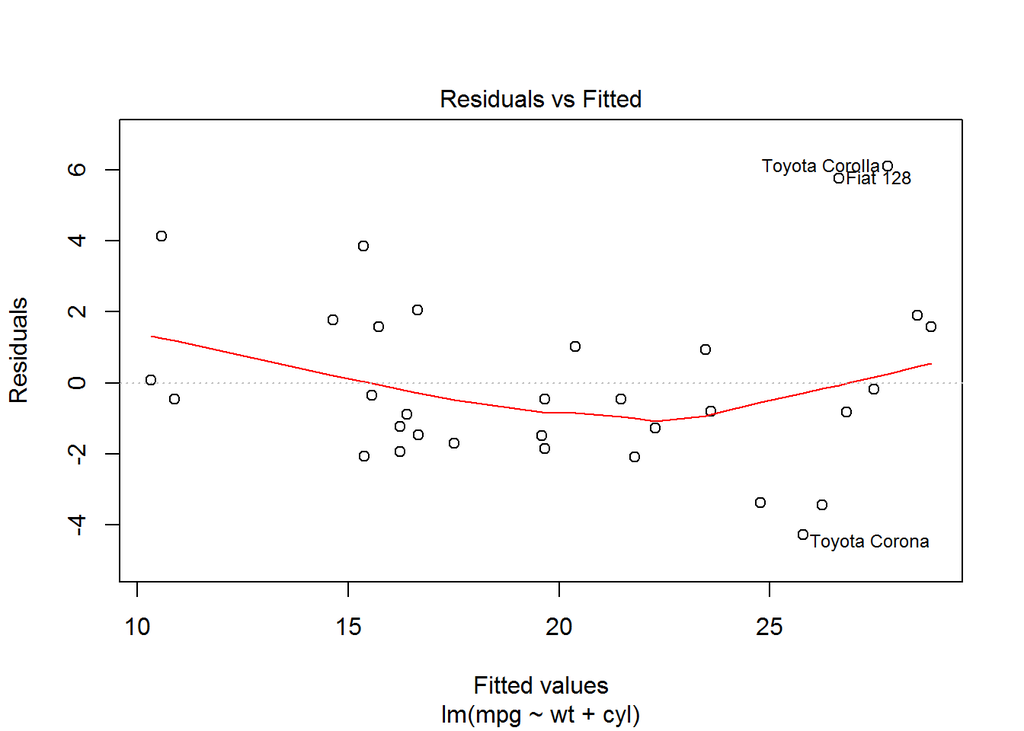

```r
plot(m3,1)
```

## Residuenplot

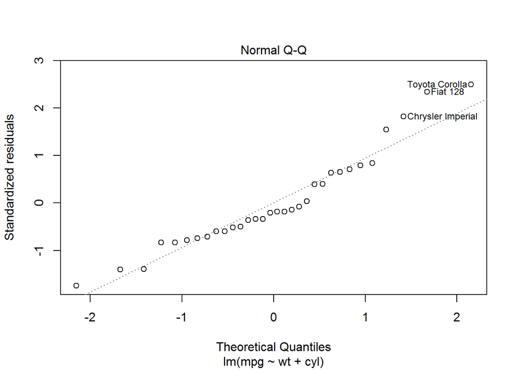

```r
plot(m3,2)
```

- Wenn die Residuen normalverteilt sind, dann sollten sie auf der gleichen Linie liegen.

## Regressionsdiagnostik mit Basis-R

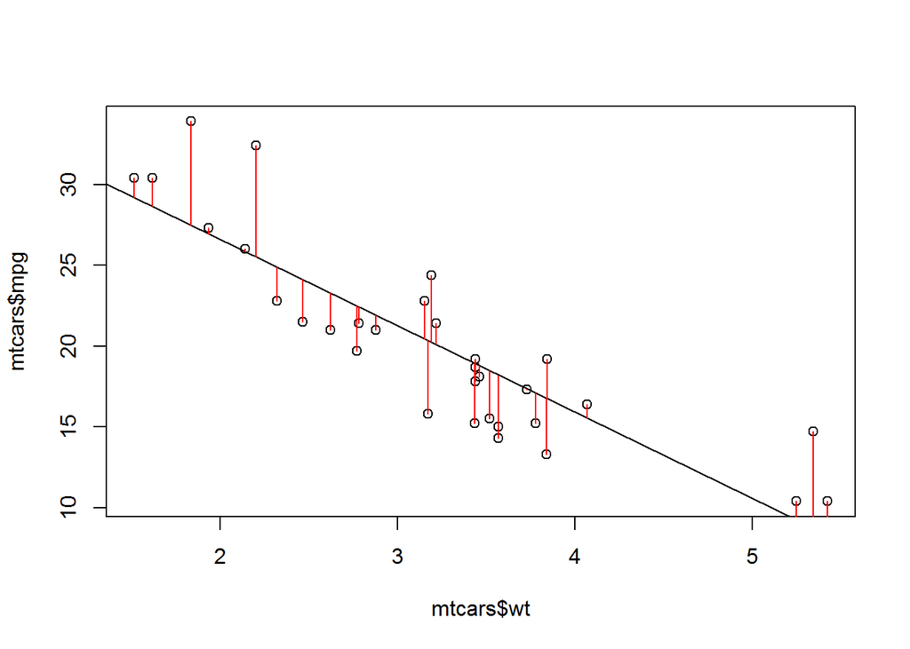

```r
plot(mtcars$wt,mtcars$mpg)
abline(m1)
segments(mtcars$wt, mtcars$mpg, mtcars$wt, pre, col="red")
```

## Das `visreg`-Paket

```r
install.packages("visreg")
```

```r
library(visreg)
```

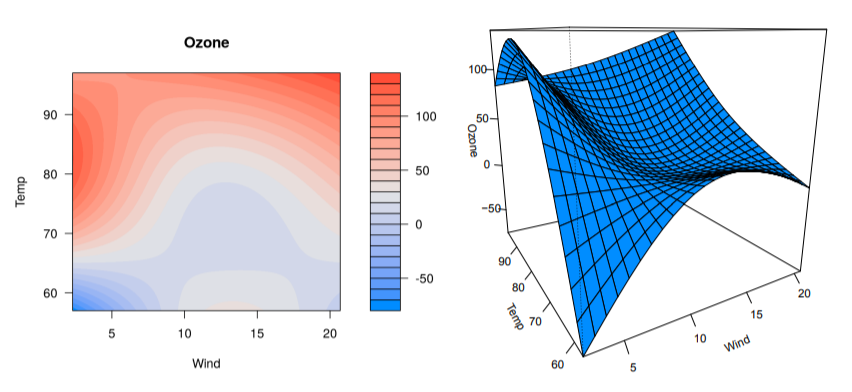

## Das `visreg`-Paket

- Das Default-Argument für `type` ist `conditional`.
- Scatterplot von `mpg` und `wt` mit Regressionslinie und Konfidenzbändern

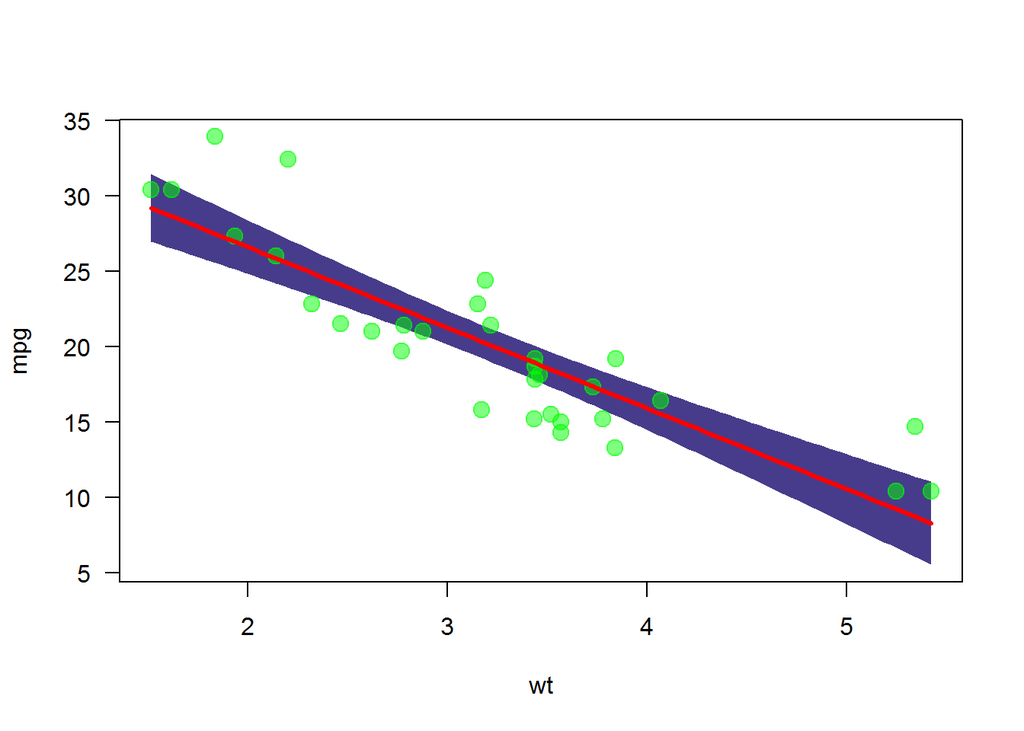

```r
visreg(m1, "wt", type = "conditional")
```

## [**Visualisierung mit `visreg`**](http://myweb.uiowa.edu/pbreheny/publications/visreg.pdf)

- [Zweites Argument](http://pbreheny.github.io/visreg) - Spezifikation der Kovariaten in der Graphik
- Das Diagramm zeigt die Auswirkung auf den erwarteten Wert des Regressors, wenn die Variable x von einem Referenzpunkt auf der x-Achse wegbewegt wird (bei numerischen Variablen der Mittelwert).

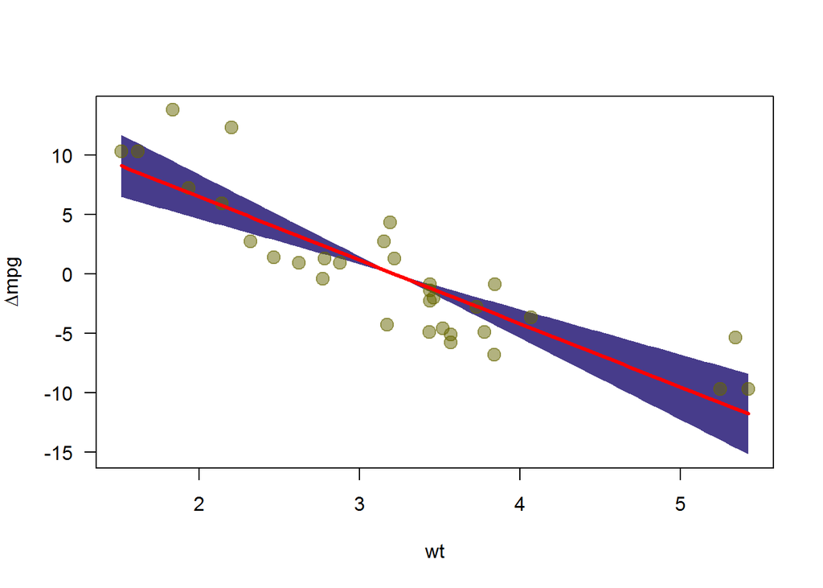

```r
visreg(m1, "wt", type = "contrast")
```

## Regression mit Faktoren

- Die Effekte von Faktoren können auch mit `visreg` visualisiert werden:

```r
mtcars$cyl <- as.factor(mtcars$cyl)
m4 <- lm(mpg ~ cyl + wt, data = mtcars)
# summary(m4)
```

```
##              Estimate Std. Error   t value     Pr(>|t|)
## (Intercept) 33.990794  1.8877934 18.005569 6.257246e-17
## cyl6        -4.255582  1.3860728 -3.070244 4.717834e-03
## cyl8        -6.070860  1.6522878 -3.674214 9.991893e-04
## wt          -3.205613  0.7538957 -4.252065 2.130435e-04
```

## Effekte von Faktoren

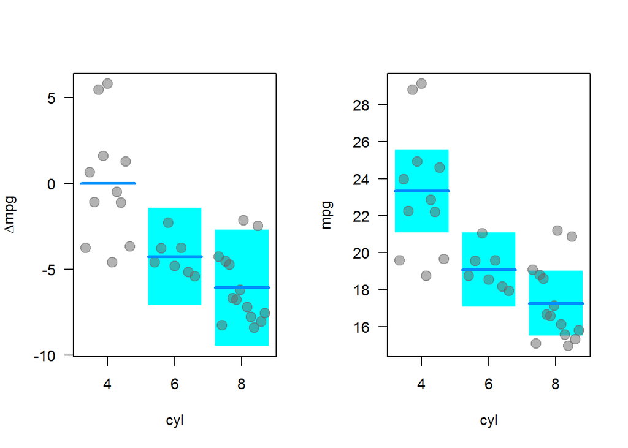

```r
par(mfrow=c(1,2))
visreg(m4, "cyl", type = "contrast")
visreg(m4, "cyl", type = "conditional")
```

## Das Paket `visreg` - Interaktionen

```r
m5 <- lm(mpg ~ cyl*wt, data = mtcars)
# summary(m5)
```

```
##               Estimate Std. Error    t value     Pr(>|t|)
## (Intercept)  39.571196   3.193940 12.3894599 2.058359e-12
## cyl6        -11.162351   9.355346 -1.1931522 2.435843e-01
## cyl8        -15.703167   4.839464 -3.2448150 3.223216e-03
## wt           -5.647025   1.359498 -4.1537586 3.127578e-04
## cyl6:wt       2.866919   3.117330  0.9196716 3.661987e-01
## cyl8:wt       3.454587   1.627261  2.1229458 4.344037e-02
```

## Den Graphikoutput mit `layout` kontrollieren

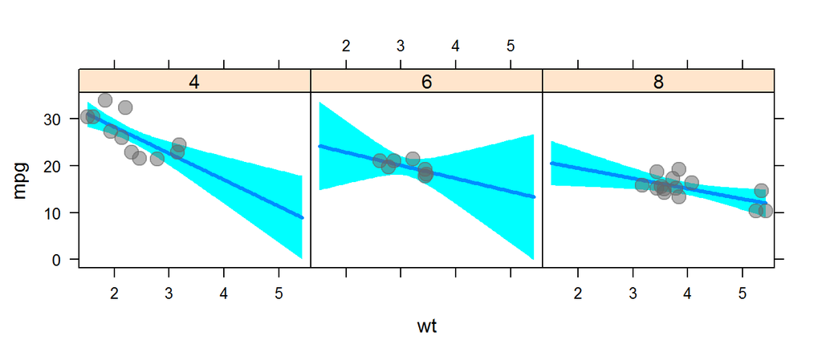

```r
visreg(m5, "wt", by = "cyl",layout=c(3,1))
```

## Das Paket `visreg` - Interaktionseffekte übereinander legen

```r
m6 <- lm(mpg ~ hp + wt * cyl, data = mtcars)
```

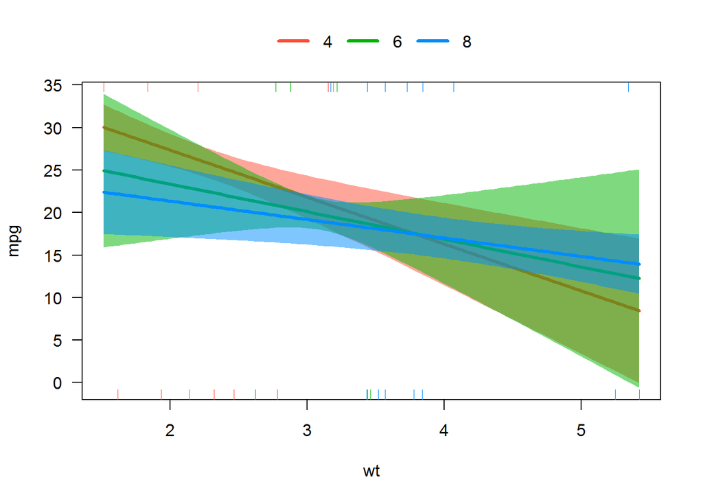

```r
visreg(m6, "wt", by="cyl", overlay=TRUE, partial=FALSE)
```

## Das Paket `visreg` - `visreg2d`

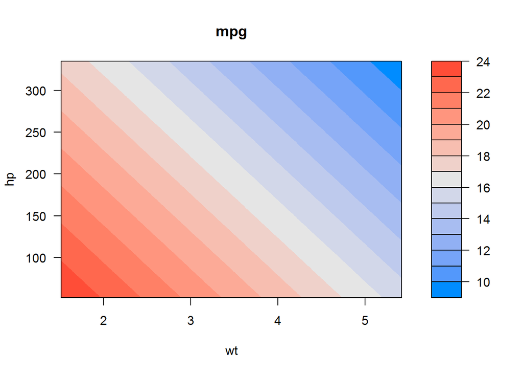

```r
visreg2d(m6, "wt", "hp", plot.type = "image")
```

## Das Paket `visreg` - `surface`

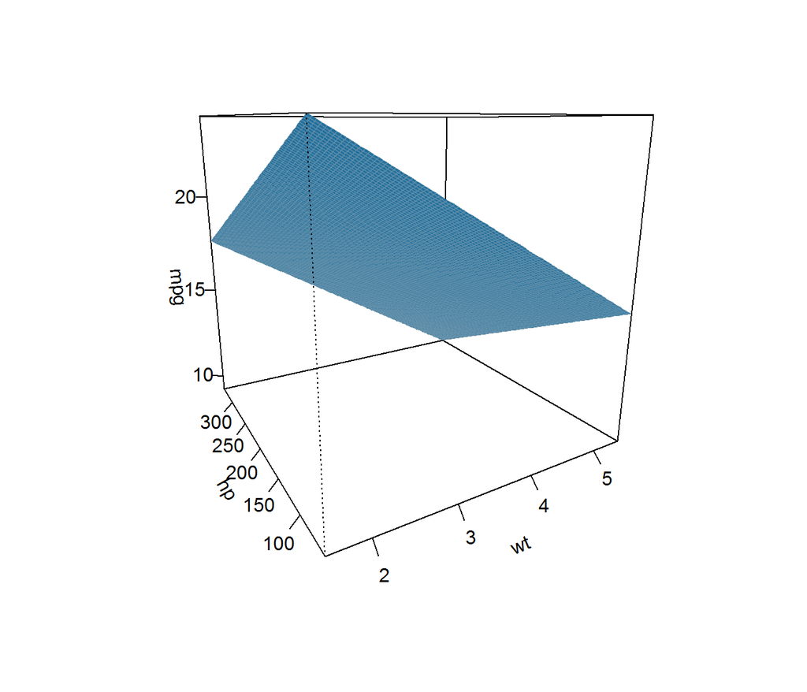

```r
visreg2d(m6, "wt", "hp", plot.type = "persp")
```

## B3A Aufgabe lineare Regression

Der Datensatz `toycars` beschreibt die Route von drei Spielzeugautos, die Rampen in verschiedenen Winkeln absteigen.

- angle: Rampenwinkel
- distance: Entfernung die von dem Spielzeugauto zurück gelegt wird.
- car: Autotyp (1, 2 or 3)
1. Lese den Datensatz `toycars` ein und konvertiere die Variable `car` des Datensatzes in einen Faktor (`as.factor`).
2. Erstelle drei Box-Plots, in denen die von den Autotypen zurückgelegte Strecke visualisiert wird.

## B3A Aufgabe lineare Regression II

3. Schätze für jeden Autotyp getrennt die Parameter des folgenden linearen Modell; nutze dafür die Funktion `lm()`

$$distance_i= \beta_0 + \beta_1 \cdot angle_i + \epsilon_i$$

4. Überprüfe die Anpassung des Modells indem Du die drei Regressionslinien in den Scatterplot einzeichnest (`distance` gegen `angle`). Spricht das
   $$R^2$$
   für eine gute Modellanpassung?

## Einen schönen Output mit dem Paket [**`stargazer`**](https://cran.r-project.org/web/packages/stargazer/vignettes/stargazer.pdf)

erzeugen

```r
library(stargazer)
stargazer(m3, type="html")
```

### Beispiel HTML Outputs:

[figure not shown]

## Shiny App - Diagnostiken für die einfache lineare Regression

https://gallery.shinyapps.io/slr_diag/

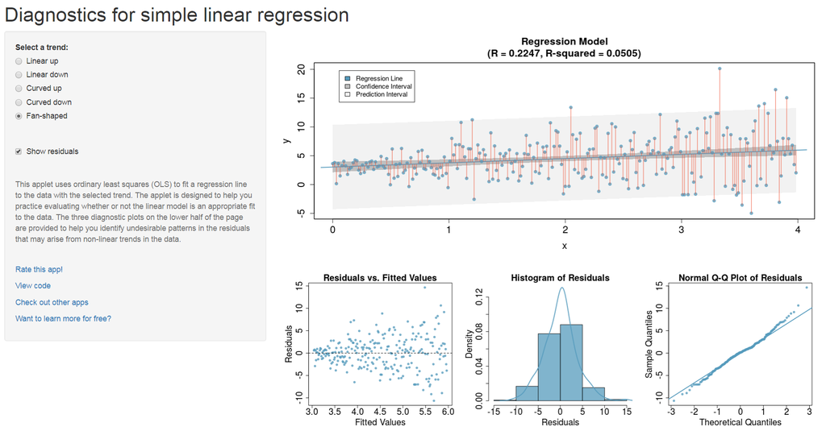

- Shiny App - [**Eine einfache lineare Regression**](https://gallery.shinyapps.io/simple_regression/)
- Shiny App - **Multikollinearität in multiplen Regressionen testen**

## Links - lineare Regression

- Regression - [**r-bloggers**](http://www.r-bloggers.com/r-tutorial-series-simple-linear-regression/)
- Das komplette Buch von [**Faraway**](http://cran.r-project.org/doc/contrib/Faraway-PRA.pdf)- sehr intuitiv geschriebenes Buch
- Gute Einführung auf [**Quick-R**](http://www.statmethods.net/stats/regression.html)
- [**Multiple Regression**](https://www.r-bloggers.com/multiple-regression-part-1/)
- [**15 Arten von Regressionen die man kennen sollte**](https://www.r-bloggers.com/15-types-of-regression-you-should-know/)
- [**`ggeffects` - Erzeuge saubere Datensätze mit marginellen Effekten für ‘ggplot’ aus Modell Outputs**](https://strengejacke.github.io/ggeffects/)